# Google scholar

Vignette for the {scholar} package: https://cran.r-project.org/web/packages/scholar/vignettes/scholar.html

Before running the first time, we need to make sure the {scholar} package is installed. This only needs to be done once.

```r
install.packages("scholar")
```

Every time we open R or RStudio up we need to load the libraries that contain the functions that are additional to the functions that are included by default. I.e. the functions that are particular to this analysis.

```r
library(scholar)
library(tidyverse)
```

Find Google Scholar ID

The example in the vignette was for Richard Feynman, but we need to get a google scholar ID to use the package. I did this by searching “Richard Feynman” in scholar.google.com and clicked through on the author profile. I then copied the url.

https://scholar.google.co.nz/citations?hl=en&user=B7vSqZsAAAAJ

Based on the API lesson we can look at the URL for the profile and the bit after ‘user=’ should be the ID; B7vSqZsAAAAJ

```r
## Define the id for Richard Feynman
id <- 'B7vSqZsAAAAJ'


## Get his profile
scholar_profile <- get_profile(id)

# what is contained in a profile?
str(scholar_profile)
```

```
## List of 9
##  $ id         : chr "B7vSqZsAAAAJ"
##  $ name       : chr "Richard Feynman"
##  $ affiliation: chr "California Institute of Technology"
##  $ total_cites: num 93163
##  $ h_index    : num 62
##  $ i10_index  : num 95
##  $ fields     : chr "no verified email"
##  $ homepage   : chr(0)
##  $ coauthors  : chr ""
```

```r
## Print his name and affliation
scholar_profile$name
```

```
## [1] "Richard Feynman"
```

So this is telling us some information about the author that google scholar has.

We can also get information about his publications

```r
pubs <- get_publications(id)

# look at the information for the first 3
head(pubs, 3)
```

```
##                                    title
## 1 Quantum mechanics and path integration
## 2        The Feynman lectures on physics
## 3      Simulating physics with computers
##                                         author
## 1                         RP Feynman, AR Hibbs
## 2 RP Feynman, RB Leighton, M Sands, SB Treiman
## 3                                   RP Feynman
##                                        journal          number cites year
## 1                                  McGraw–Hill                 25619 1965
## 2                                Physics Today          17, 45 14839 1964
## 3 International journal of theoretical physics 21 (6), 467-488  7164 1982
##                                                                                                      cid
## 1                                         14769952204323476283,12091496877795411869,17914366645132260192
## 2 14769952204323476283,15649786516955137750,9010733094641920532,13112633961799421939,3669163321259408309
## 3                                                                                   10235205812612705711
##          pubid
## 1 hMod-77fHWUC
## 2 u-x6o8ySG0sC
## 3 d1gkVwhDpl0C
```

We can retrieve information about his citation history

```r
## Get his citation history, i.e. citations to his work in a given year
ct <- get_citation_history(id)
```

What does the data we get back look like?

```r
head(ct)
```

```
##   year cites
## 1 1980   722
## 2 1981   702
## 3 1982   598
## 4 1983   599
## 5 1984   658
## 6 1985   661
```

We can visualise this information by plotting the number of cites (y) by year (x) to see if there is a trend.

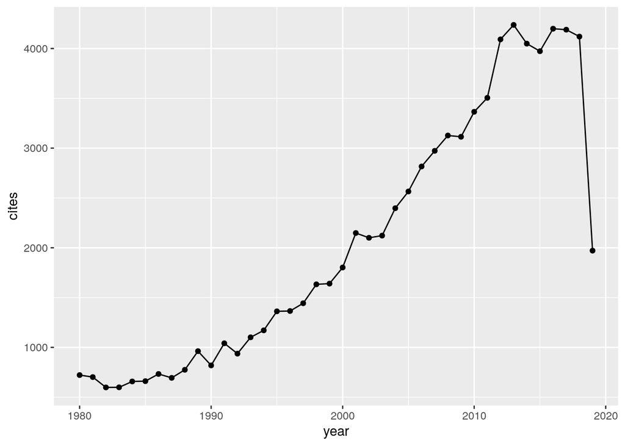

```r
## Plot citation trend
ggplot(ct, aes(x = year, y = cites)) + geom_line() + geom_point()
```

Users can retrieve the citation history of a particular publication with get_article_cite_history().

We’ll use the first publication in the list from get_publications() earlier.

```r
head(pubs, 1)
```

```
##                                    title               author     journal
## 1 Quantum mechanics and path integration RP Feynman, AR Hibbs McGraw–Hill
##   number cites year
## 1        25619 1965
##                                                              cid
## 1 14769952204323476283,12091496877795411869,17914366645132260192
##          pubid
## 1 hMod-77fHWUC
```

We can get the citation history for this particular article with get_article_cite_history(). We need to provide it the author id, and the publication id foe our article of choice

```r
## Get article citation history
article_cites <- get_article_cite_history(id, pubs$pubid[1])
```

What is the information we get back?

```r
head(article_cites)
```

```
##   year cites        pubid
## 1 1980   127 hMod-77fHWUC
## 2 1981   163 hMod-77fHWUC
## 3 1982   138 hMod-77fHWUC
## 4 1983   163 hMod-77fHWUC
## 5 1984   212 hMod-77fHWUC
## 6 1985   209 hMod-77fHWUC
```

We can plot this information to see how citiations changed over time for this particular article

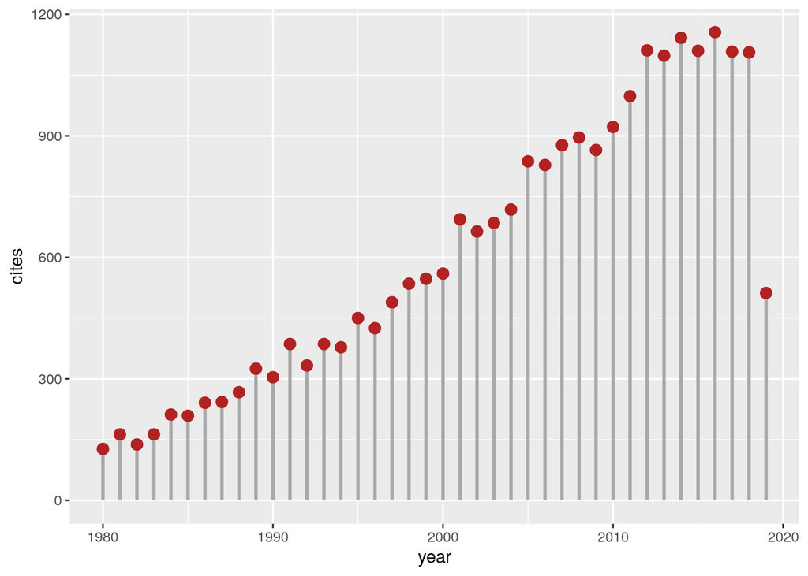

```r
## Plot citation trend
ggplot(article_cites, aes(x = year, y = cites)) +
    geom_segment(aes(xend = year, yend = 0), size=1, color='darkgrey') +
    geom_point(size=3, color='firebrick')
```

We can also compare authors

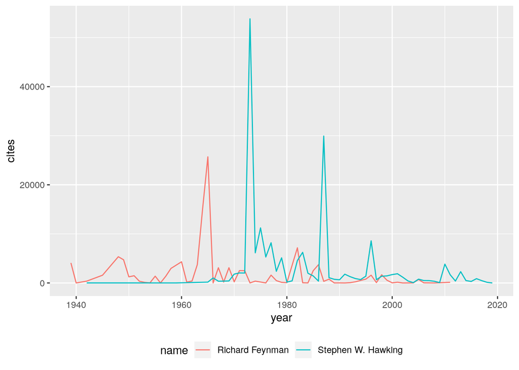

```r
# Compare Feynman and Stephen Hawking
ids <- c('B7vSqZsAAAAJ', 'qj74uXkAAAAJ')

# Get a data frame comparing the number of citations to their work in
# a given year
cs <- compare_scholars(ids)

## remove some 'bad' records without sufficient information
cs <- filter(cs, !is.na(year) & year > 1900)
ggplot(cs, aes(year, cites, group=name, color=name)) + geom_line() + theme(legend.position="bottom")
```

We can also visualise co-author networks

```r
coauthor_network <- get_coauthors('amYIKXQAAAAJ&hl', n_coauthors = 7)
coauthor_network
```

```
##                        author                  coauthors
## 1  Herman G. Van De Werfhorst                  Thijs Bol
## 2  Herman G. Van De Werfhorst            Daniele Checchi
## 3  Herman G. Van De Werfhorst         Frank Van Tubergen
## 4  Herman G. Van De Werfhorst         István György Tóth
## 5  Herman G. Van De Werfhorst            Wiemer Salverda
## 6  Herman G. Van De Werfhorst Jonathan Jan Benjamin Mijs
## 7  Herman G. Van De Werfhorst          Nan Dirk De Graaf
## 8                   Thijs Bol Herman G. Van De Werfhorst
## 9                   Thijs Bol          Andrea G. Forster
## 10                  Thijs Bol              Jaap Dronkers
## 11                  Thijs Bol              Kim A. Weeden
## 12                  Thijs Bol                Bram Lancee
## 13                  Thijs Bol     Christina Ciocca Eller
## 14                  Thijs Bol         Arnout Van De Rijt
```

[output cut: 42 more lines]

Plot the network

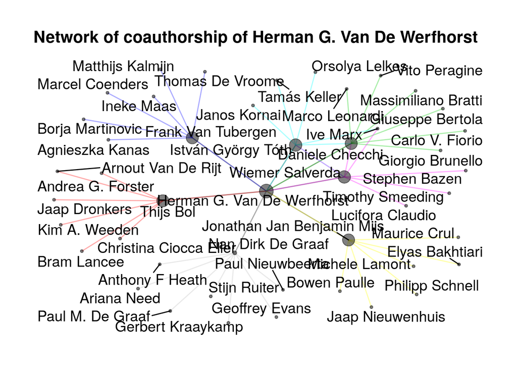

```r
plot_coauthors(coauthor_network)
```

A slightly different version of the plot is used in this example https://andreacontina.com/google-scholar/